# Solving Games for NE

with Connor T. Wiegand

### Recall: BRs and NE

- Best response function: maps opponents’ strategies to ones own best responses
- Nash equilibrium:
  - Mutual (*intersection of*) best responses
  - No unilateral deviations

### NE: Chicken

- Let’s practice underlining best responses again

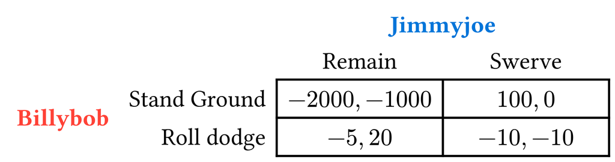

### NE: Chicken –Solved

- NE: (RD, R) and (SG, S)

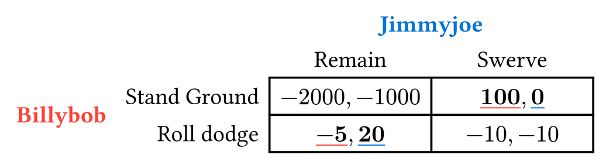

### NE-Ex

- This is a totally made up game, but it’s good practice

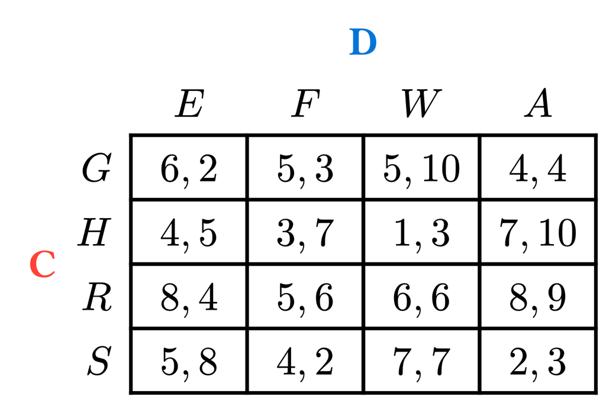

### NE-Ex –Solved

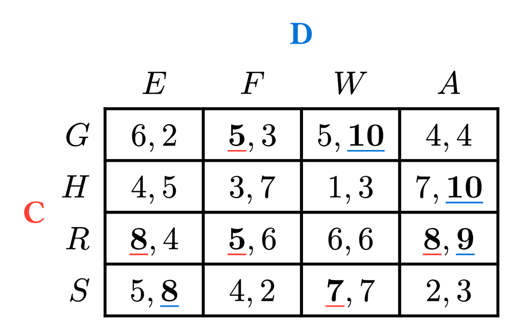

### Matching Pennies

- Sean
  - $BR_S(H)=H$
  - $BR_S(T)=T$
- Bean
  - $BR_B(H)=T$
  - $BR_B(T)=H$

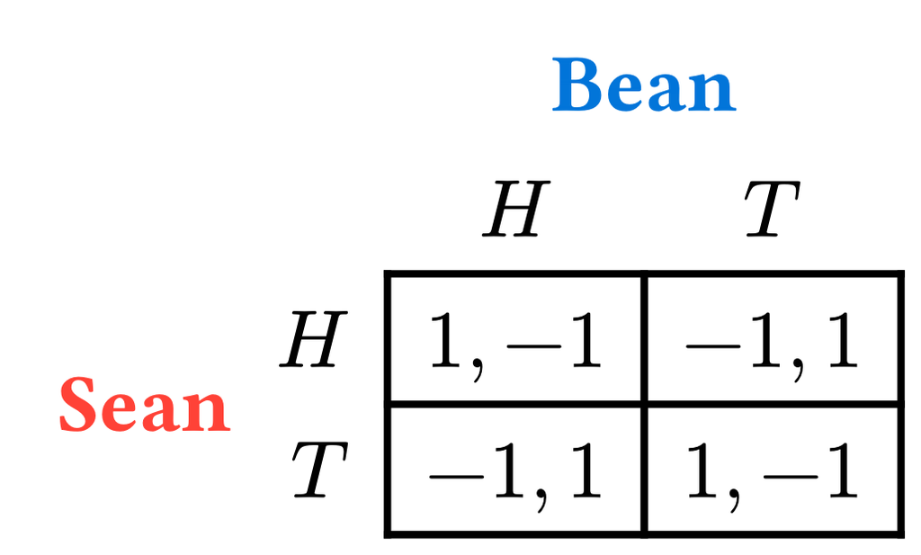

### Matching Pennies –Solved?

- So…there’s no NE?
  - How do we make a good prediction?

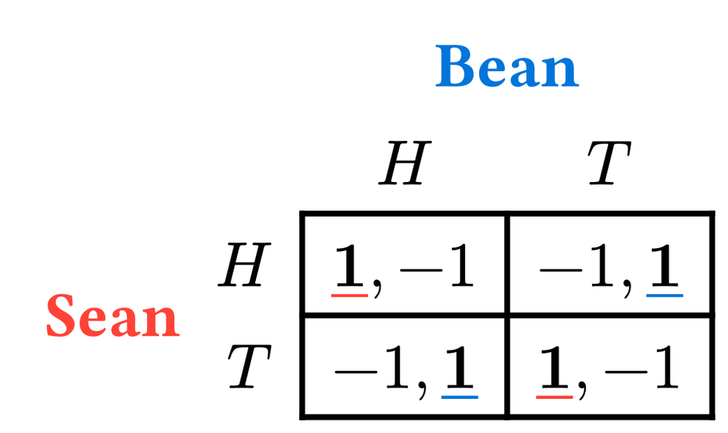

### Probabilistic Play

- What if players did not play every game the same way?
  - Think of Rock, Paper, Scissors
- Abstracting away from *how* our opponent may make a randomized<sup>1</sup> decision, let’s simply model their “random” strategy according to the probability that they select each of their moves
- E.g. $(p_{H})\cdot H + (p_{T})\cdot T$
  - That is, $p_{H}\equiv$ the probability that Sean plays Heads
  - Likewise, $p_{T}\equiv$ the probability that Sean plays Tails
[^1]: or *stochastic*

### Mixed Strategies

- Such a strategy is called a Mixed Strategy
- Contrast to *pure* strategies – what we have been discussing thus far
  - $s_{i}\in S_i$ denotes a pure strategy in a player’s space of pure strategies
  - $\sigma_{i}(\cdot)\in \Sigma_{i}$ denotes a mixed strategy in a player’s space of mixed strategies
- With mixed strategies, we now want to make explicit that we are thinking about players expected payoffs

### Sean’s Expected Payoffs

- Sean’s strategy: let’s call it $\sigma_S$:
  $$\sigma_S=p_{H}H + p_{T}T$$
- Note: we denote the expected value with the $E[\cdot]$ operator. Hence, $E[u_{i}(\cdot)]$(or $E[\pi_i(\cdot)]$) denote expected payoffs.
- What is $E[u_S(\sigma_S, H)]$? $E[u_S(\sigma_S, T)]$?
  - $E[u_S(\sigma_S, H)]= p_{H} \cdot u_S(H,H) + p_T \cdot u_S(T,H) = p_H - p_T$
  - $E[u_S(\sigma_S, T)]= p_{H} \cdot u_S(H,T) + p_T \cdot u_S(T,T) = p_T - p_H$
- This generates two new questions for us
  - What are probabilities are reasonable to play?
  - Why would someone play such a strategy?

### The importance of mixed strategies

- What Nash did for his dissertation
- **Theorem**: *Every “reasonable” game has a Nash Equilibria*
  - Remarks
    - I want you to assume that every game I show you in this class is “reasonable”
    - In particular, I’m never looking for the answer “this game does not have any NE”
    - Maybe none *of a certain flavor* or *class*, but not “none”
  - “Reasonable”
    - Every game with a finite strategy space
    - If infinite strategies $\implies$ need compact strategy space<sup>1</sup>
[^2]: basically…bounded + no holes

### When will someone play a mixed strategy?

- Let’s take for granted that Sean might be playing a mixed strategy
- Given this, Bean is thinking about playing a mixed strategy as well. When does it make sense to do so?
  - Let’s compare $E[u_B(\sigma_S, H)]$ vs. $E[u_B(\sigma_S, T)]$
1. Suppose $E[u_B(\sigma_S, H)] > E[u_B(\sigma_S, T)]$
   - What does this say in words?
   - “Bean gets a higher e.p.<sup>1</sup> from playing H than T”
   - So: does Bean have any reason to play $T$?
     - No! That would be adding probability to a worse outcome
     - Bean should just play $H$
[^3]: expected payoff

### When will someone play a mixed strategy? (cont.)

1. Suppose $E[u_B(\sigma_S, H)] > E[u_B(\sigma_S, T)]$
   - “Bean gets a higher e.p. from playing H than T”
   - So Bean should just play $H$
2. Instead suppose $E[u_B(\sigma_S, H)] < E[u_B(\sigma_S, T)]$
   - “Bean gets a higher e.p. from playing T than H”
   - Does Bean have any reason to play $H$?
     - No! Bean should just play $T$
- Should you ever play a mixed strategy that includes quitting?
  - Not if you want to win
  - “Juking out your opponent” doesn’t work if it’s too dumb

### When will someone play a mixed strategy? (cont.)

1. Suppose $E[u_B(\sigma_S, H)] > E[u_B(\sigma_S, T)]$
   - Bean should just play $H$
2. Suppose $E[u_B(\sigma_S, H)] < E[u_B(\sigma_S, T)]$
   - Bean should just play $T$
3. What if $E[u_B(\sigma_S, H)] = E[u_B(\sigma_S, T)]$?
   - What does this say in words?
   - “Bean is *indifferent* between playing $H$ and $T$”
- If Bean gets equal (expected) payoffs from playing either pure strategy, then (and only then) will they have reason to play a mixed strategy
- This holds true in general:
  - An agent will only play a mixed strategy when they are indifferent between a subset of their pure strategies, *holding fixed what the other player is doing*
  - …and, assuming these strategies are the best pure strategies they can play, in response to the opponent’s strategy
    - Ex. scream $\sim$ cry, but **try** is better than both

### How do we find MSNE?

- It’s complicated…we’ll return to this later
- For now, I primarily want you to know when/why players mix and Nash’s existence theorem

### Never Best Responses

- Def [Version 1.0]: A (pure) strategy $\tilde{s}\in S_{i}$ is said to be Never a Best Response provided that $\tilde{s}\notin BR_{i}(s_{-i})$ for any $s_{-i}\in S_{-i}$
- How is this related to strict/weak domination?

### NBR Example

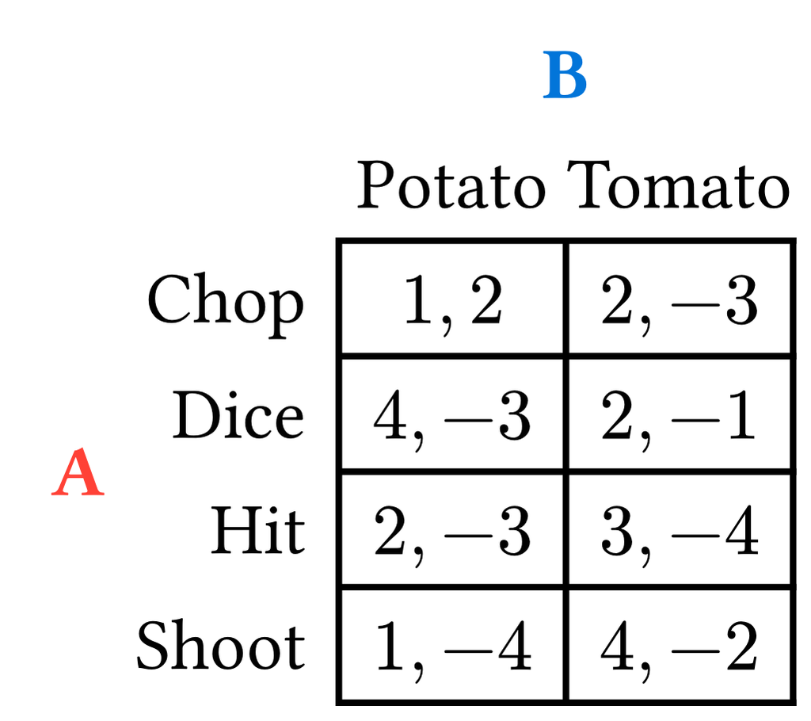

- $H \succ_{SD} C$ for $P_A$
  - and $C$ is NBR
- Hit is not dominated by anything for $P_A$
  - but Hit is still NBR

### Never Best Responses

- Def [Version 1.0]: A (pure) strategy $\tilde{s}\in S_{i}$ is said to be Never a Best Response provided that $\tilde{s}\notin BR_{i}(s_{-i})$ for any $s_{-i}\in S_{-i}$
- How is this related to strict/weak domination?
- **Fact:** a strictly dominated strategy is never a best response
  - Why?
- Do we want to eliminate NBRs *a la* IDSDS?
  - No, at least not using this definition
  - We will return to this later, when we resume mixed strategies